# RESTRICTED BOLTZMANN MACHINES

Created on JupyterLab

### Introduction

**Restricted Boltzmann Machine (RBM):** RBMs are shallow neural nets that **learn to reconstruct data by themselves in an unsupervised fashion.**

#### Why are RBMs important?

An RBM are a basic form of **autoencoder.** It can automatically **extract **meaningful** features from a given input.**

#### How does it work?

RBM is a **2 layer neural network.** Simply, RBM takes the inputs and translates those into a set of **binary values that represents them in the hidden layer.** Then, these numbers can be **translated back to reconstruct the inputs.** Through several **forward and backward passes**, the RBM will be trained, and a **trained RBM can reveal which features are the most important ones when detecting patterns.**

#### What are the applications of an RBM?

RBM is useful for Collaborative Filtering, dimensionality reduction, classification, regression, feature learning, topic modeling and even **Deep Belief Networks**.

#### Is RBM a generative or Discriminative model?

**RBM is a generative model.** Let me explain it by first, see what is different between discriminative and generative models:

**Discriminative:** Consider a classification problem where we want to learn to distinguish between Sedan cars (y = 1) and SUV cars (y = 0), based on some features of cars. Given a training set, an algorithm like logistic regression tries to find a straight line, or *decision boundary*, that separates the suv and sedan.

**Generative:** **looking at cars, we can build a model of what Sedan cars look like.** Then, **looking at SUVs, we can build a separate model of what SUV cars look like.** Finally, to **classify a new car**, we can match the new car against the Sedan model, and match it against the SUV model, to see whether the new car looks more like the SUV or Sedan.

Generative Models specify a **probability distribution over a dataset of input vectors.** We can carry out **both supervised and unsupervised tasks with generative models**:

- In an unsupervised task, we try to form a model for $P(x)$, where $P$ is the probability given $x$ as an input vector.
- In the supervised task, we first form a model for $P(x|y)$, where $P$ is the probability of $x$ given $y$(the label for $x$). For example, if $y = 0$ indicates that a car is an SUV, and $y = 1$ indicates that a car is a sedan, then $p(x|y = 0)$ models the distribution of SUV features, and $p(x|y = 1)$ models the distribution of sedan features. If we manage to find $P(x|y)$ and $P(y)$, then we can use **Bayes rule** to estimate $P(y|x)$, because: $$p(y|x) = \frac{p(x|y)p(y)}{p(x)}$$

Now the question is, can we build a generative model, and then use it to create synthetic data by directly sampling from the modeled probability distributions? Lets see.

## Table of Contents

1. Initialization
2. RBM layers
3. What RBM can do after training?
4. How to train the model?
5. Learned features

### Initialization

First, we have to load the utility file which contains different utility functions that are not connected in any way to the networks presented in the tutorials, but rather help in processing the outputs into a more understandable way.

```python
import urllib.request
with urllib.request.urlopen("https://cf-courses-data.s3.us.cloud-object-storage.appdomain.cloud/IBMDeveloperSkillsNetwork-DL0120EN-SkillsNetwork/labs/Week4/data/utils.py") as url:
    response = url.read()
target = open('utils.py', 'w')
target.write(response.decode('utf-8'))
target.close()
```

## Installing TensorFlow

We will installing TensorFlow version 2.9.0 and its required prerequistes. Also installing pillow...

```python
#!pip install grpcio==1.24.3
#!pip install tensorflow==2.9.0
#!pip install pillow==8.1.0
```

**Notice:** This notebook has been created with TensorFlow version 2.9.0, and might not work with other versions. Therefore we check:

```python
import tensorflow as tf
from IPython.display import Markdown, display

def printmd(string):
    display(Markdown('# <span style="color:red">'+string+'</span>'))


if not tf.__version__ == '2.9.0':
    printmd('<<<<<!!!!! ERROR !!!! please upgrade to TensorFlow 2.9.0, or restart your Kernel (Kernel->Restart & Clear Output)>>>>>')
```

[output not shown]

Now, we load in all the packages that we use to create the net including the TensorFlow package:

```python
""" This file contains different utility functions that are not connected
in anyway to the networks presented in the notebook, but rather help in
processing the outputs into a more understandable way.

For example ``tile_raster_images`` helps in generating a easy to grasp
image from a set of samples or weights.
"""

import numpy


def scale_to_unit_interval(ndar, eps=1e-8):
    """ Scales all values in the ndarray ndar to be between 0 and 1 """
    ndar = ndar.copy()
    ndar -= ndar.min()
    ndar *= 1.0 / (ndar.max() + eps)
    return ndar


def tile_raster_images(X, img_shape, tile_shape, tile_spacing=(0, 0),
                       scale_rows_to_unit_interval=True,
                       output_pixel_vals=True):
    """
    Transform an array with one flattened image per row, into an array in
    which images are reshaped and layed out like tiles on a floor.

    This function is useful for visualizing datasets whose rows are images,
    and also columns of matrices for transforming those rows
    (such as the first layer of a neural net).

    :type X: a 2-D ndarray or a tuple of 4 channels, elements of which can
    be 2-D ndarrays or None;
    :param X: a 2-D array in which every row is a flattened image.

    :type img_shape: tuple; (height, width)
    :param img_shape: the original shape of each image

    :type tile_shape: tuple; (rows, cols)
    :param tile_shape: the number of images to tile (rows, cols)

    :param output_pixel_vals: if output should be pixel values (i.e. int8
    values) or floats

    :param scale_rows_to_unit_interval: if the values need to be scaled before
    being plotted to [0,1] or not


    :returns: array suitable for viewing as an image.
    (See:`Image.fromarray`.)
    :rtype: a 2-d array with same dtype as X.

    """

    assert len(img_shape) == 2
    assert len(tile_shape) == 2
    assert len(tile_spacing) == 2

    # The expression below can be re-written in a more C style as
    # follows :
    #
    # out_shape    = [0,0]
    # out_shape[0] = (img_shape[0]+tile_spacing[0])*tile_shape[0] -
    #                tile_spacing[0]
    # out_shape[1] = (img_shape[1]+tile_spacing[1])*tile_shape[1] -
    #                tile_spacing[1]
    out_shape = [
        (ishp + tsp) * tshp - tsp
        for ishp, tshp, tsp in zip(img_shape, tile_shape, tile_spacing)
    ]

    if isinstance(X, tuple):
        assert len(X) == 4
        # Create an output numpy ndarray to store the image
        if output_pixel_vals:
            out_array = numpy.zeros((out_shape[0], out_shape[1], 4),
                                    dtype='uint8')
        else:
            out_array = numpy.zeros((out_shape[0], out_shape[1], 4),
                                    dtype=X.dtype)

        #colors default to 0, alpha defaults to 1 (opaque)
        if output_pixel_vals:
            channel_defaults = [0, 0, 0, 255]
        else:
            channel_defaults = [0., 0., 0., 1.]

        for i in range(4):
            if X[i] is None:
                # if channel is None, fill it with zeros of the correct
                # dtype
                dt = out_array.dtype
                if output_pixel_vals:
                    dt = 'uint8'
                out_array[:, :, i] = numpy.zeros(
                    out_shape,
                    dtype=dt
                ) + channel_defaults[i]
            else:
                # use a recurrent call to compute the channel and store it
                # in the output
                out_array[:, :, i] = tile_raster_images(
                    X[i], img_shape, tile_shape, tile_spacing,
                    scale_rows_to_unit_interval, output_pixel_vals)
        return out_array

    else:
        # if we are dealing with only one channel
        H, W = img_shape
        Hs, Ws = tile_spacing

        # generate a matrix to store the output
        dt = X.dtype
        if output_pixel_vals:
            dt = 'uint8'
        out_array = numpy.zeros(out_shape, dtype=dt)

        for tile_row in range(tile_shape[0]):
            for tile_col in range(tile_shape[1]):
                if tile_row * tile_shape[1] + tile_col < X.shape[0]:
                    this_x = X[tile_row * tile_shape[1] + tile_col]
                    if scale_rows_to_unit_interval:
                        # if we should scale values to be between 0 and 1
                        # do this by calling the `scale_to_unit_interval`
                        # function
                        this_img = scale_to_unit_interval(
                            this_x.reshape(img_shape))
                    else:
                        this_img = this_x.reshape(img_shape)
                    # add the slice to the corresponding position in the
                    # output array
                    c = 1
                    if output_pixel_vals:
                        c = 255
                    out_array[
                        tile_row * (H + Hs): tile_row * (H + Hs) + H,
                        tile_col * (W + Ws): tile_col * (W + Ws) + W
                    ] = this_img * c
        return out_array
```

```python
import tensorflow as tf
import numpy as np

from PIL import Image
import matplotlib.pyplot as plt
%matplotlib inline
```

### RBM layers

An RBM has two layers. The first layer of the RBM is called **the **visible** (or input layer).** Imagine that our toy example, has only vectors with 7 values, so the visible layer must have $V=7$ input nodes. The second layer is **the **hidden** layer**, which has $H$ neurons in our case. **Each hidden node takes on values of either 0 or 1 (i.e., $h_i = 1$ or $h_i$ = 0)**, with a **probability that is a logistic function** of the inputs it receives from the other $V$ visible units, called for example, $p(h_i = 1)$. For our toy sample, we'll use 2 nodes in the hidden layer, so $H = 2$.

[figure not shown]

```python
v_bias = tf.Variable(tf.zeros([7]), tf.float32)
h_bias = tf.Variable(tf.zeros([2]), tf.float32)
```

[output not shown]

We have to define weights among the input layer and hidden layer nodes. In the weight matrix, the number of rows are equal to the input nodes, and the number of columns are equal to the output nodes. We define a tensor $\mathbf{W}$ of shape = (7,2), where the number of visible neurons = 7, and the number of hidden neurons = 2.

```python
W = tf.constant(np.random.normal(loc=0.0, scale=1.0, size=(7, 2)).astype(np.float32))
W.shape
```

```
TensorShape([7, 2])
```

### What RBM can do after training?

Think of RBM as a model that has been trained based on images of a dataset of many SUV and sedan cars. Also, imagine that the RBM network has only two hidden nodes, where one node encodes the weight and, and the other encodes the size.

In a sense, **the different configurations represent different cars, where one is an SUV and the other is Sedan**. In a training process, through many **forward and backward passes**, the RBM **adjust its weights to send a stronger signal to either the SUV node (0, 1) or the sedan node (1, 0) in the hidden layer, given the pixels of images.** Now, given an SUV in hidden layer, which distribution of pixels should we expect? RBM can give you 2 things. **First, it encodes your images in hidden layer. Second, it gives you the probability of observing a case, given some hidden values.**

### The Inference Process

RBM has two phases:

- Forward Pass
- Backward Pass or Reconstruction

**Phase 1) Forward pass:**

Input one training sample (one image) $\mathbf{x}$ through all visible nodes, and pass it to all hidden nodes. Processing happens in each node in the hidden layer. **This computation begins by making stochastic decisions about whether to transmit that input or not (i.e. to determine the state of each hidden layer).** First, the probability vector is computed using the input feature vector $\mathbf{x}$, the weight matrix $\mathbf{W}$, and the bias term $h_{bias}$, as

$$p({h_j}|\mathbf x)= \sigma( \sum_{i=1}^V W_{ij} x_i + h_{bias} )$$

,

where $\sigma(z) = (1+e^{-z})^{-1}$ is the logistic function.

So, what does $p({h_j})$ represent? It is the **probability distribution** of the hidden units. That is, RBM uses inputs $x_i$ to make predictions about hidden node activations. For example, imagine that the hidden node activation values are [0.51 0.84] for the first training item. It tells you that the conditional probability for each hidden neuron for Phase 1 is:

$$p(h_{1} = 1|\mathbf{v}) = 0.51$$$$p(h_{2} = 1|\mathbf{v}) = 0.84$$

As a result, for each row in the training set, vector of probabilities is generated. In TensorFlow, this is referred to as a `tensor` with a shape of (1,2).

Therefore, the conditional probability of a configuration of $\mathbf{h}$ given $\mathbf{v}$ (for a training sample) is:

$$p(\mathbf{h} \mid \mathbf{v}) = \prod_{j=1}^H p(h_j \mid \mathbf{v})$$

where $H$ is the number of hidden units.

Before we go further, let's look at a toy example for one case out of all input. Assume that we have a trained RBM, and a very simple input vector, such as [1.0, 0.0, 0.0, 1.0, 0.0, 0.0, 0.0].  
Let's see what the output of forward pass would look like:

```python
X = tf.constant([[1.0, 0.0, 0.0, 1.0, 0.0, 0.0, 0.0]], tf.float32)

v_state = X
print ("Input: ", v_state)

h_bias = tf.constant([0.1, 0.1])
print ("hb: ", h_bias)
print ("w: ", W)

# Calculate the probabilities of turning the hidden units on:
h_prob = tf.nn.sigmoid(tf.matmul(v_state, W) + h_bias)  #probabilities of the hidden units
print ("p(h|v): ", h_prob)

# Draw samples from the distribution:
h_state = tf.nn.relu(tf.sign(h_prob - tf.random.uniform(tf.shape(h_prob)))) #states
print ("h0 states:", h_state)
```

```
Input:  tf.Tensor([[1. 0. 0. 1. 0. 0. 0.]], shape=(1, 7), dtype=float32)
hb:  tf.Tensor([0.1 0.1], shape=(2,), dtype=float32)
w:  tf.Tensor(
[[-2.5808063e-01  1.3250563e+00]
 [ 1.2743714e+00  1.0408901e-03]
 [-4.7007278e-01  1.2767292e+00]
 [-4.1472897e-01  3.0288005e-01]
 [ 2.4884157e-01 -7.2596633e-01]
 [ 1.2166126e+00 -1.9749179e+00]
 [ 2.0956120e+00 -5.0073349e-01]], shape=(7, 2), dtype=float32)
p(h|v):  tf.Tensor([[0.3605888 0.8491483]], shape=(1, 2), dtype=float32)
h0 states: tf.Tensor([[0. 1.]], shape=(1, 2), dtype=float32)
```

**Phase 2) Backward Pass (Reconstruction):** The RBM reconstructs data by making several forward and backward passes between the visible and hidden layers.

**So, in the second phase (i.e. reconstruction phase), the samples from the hidden layer (i.e. $\mathbf h$) becomes the input in the backward pass. The same weight matrix and visible layer biases are used to passed to the sigmoid function. The reproduced output is a reconstruction which is an approximation of the original input.**

```python
vb = tf.constant([0.1, 0.2, 0.1, 0.1, 0.1, 0.2, 0.1])
print ("b: ", vb)
v_prob = tf.nn.sigmoid(tf.matmul(h_state, tf.transpose(W)) + vb)
print ("p(vi∣h): ", v_prob)
v_state = tf.nn.relu(tf.sign(v_prob - tf.random.uniform(tf.shape(v_prob))))
print ("v probability states: ", v_state)
```

```
b:  tf.Tensor([0.1 0.2 0.1 0.1 0.1 0.2 0.1], shape=(7,), dtype=float32)
p(vi∣h):  tf.Tensor(
[[0.8061299  0.55009156 0.79846525 0.5993794  0.34842572 0.14493181
  0.40113613]], shape=(1, 7), dtype=float32)
v probability states:  tf.Tensor([[1. 0. 0. 1. 1. 0. 1.]], shape=(1, 7), dtype=float32)
```

RBM learns a probability distribution over the input, and then, **after being trained, the RBM can generate new samples from the learned probability distribution.** As you know, **probability distribution**, is a mathematical function that provides the probabilities of occurrence of different possible outcomes in an experiment.

The (conditional) probability distribution over the visible units v is given by

$$p(\mathbf{v} \mid \mathbf{h}) = \prod_{i=1}^V p(v_i \mid \mathbf{h}),$$

where,

$$p(v_i \mid \mathbf{h}) = \sigma\left(\sum_{j=1}^H W_{ji} h_j + v_{bias} \right)$$

so, **given current state of hidden units and weights, what is the probability of generating [1. 0. 0. 1. 0. 0. 0.] in reconstruction phase, based on the above **probability distribution** function?**

```python
inp = X
print("input X:" , inp.numpy())

print("probablity vector:" , v_prob[0].numpy())
v_probability = 1

for elm, p in zip(inp[0],v_prob[0]) :
    if elm ==1:
        v_probability *= p
    else:
        v_probability *= (1-p)

print("probability of generating X: " , v_probability.numpy())
```

```
input X: [[1. 0. 0. 1. 0. 0. 0.]]
probablity vector: [0.8061299  0.55009156 0.79846525 0.5993794  0.34842572 0.14493181
 0.40113613]
probability of generating X:  0.01461752
```

**How similar are vectors $\mathbf{x}$ and $\mathbf{v}$?** Of course, the reconstructed values most likely will not look anything like the input vector, because our network has not been trained yet. Our objective is to train the model in such a way that the input vector and reconstructed vector to be same. Therefore, based on how different the input values look to the ones that we just reconstructed, the weights are adjusted.

## MNIST

We will be using the MNIST dataset to practice the usage of RBMs. The following cell loads the MNIST dataset.

```python
#loading training and test data
mnist = tf.keras.datasets.mnist
(trX, trY), (teX, teY) = mnist.load_data()

# showing an example of the Flatten class and operation
from tensorflow.keras.layers import Flatten
flatten = Flatten(dtype='float32')
trX = flatten(trX/255.0)
trY = flatten(trY/255.0)
```

Lets look at the dimension of the images.

MNIST images have 784 pixels, so the visible layer must have 784 input nodes. For our case, we'll use 50 nodes in the hidden layer, so i = 50.

```python
vb = tf.Variable(tf.zeros([784]), tf.float32)
hb = tf.Variable(tf.zeros([50]), tf.float32)
```

Let $\mathbf W$ be the Tensor of 784x50 (784 - number of visible neurons, 50 - number of hidden neurons) that represents weights between the neurons.

```python
W = tf.Variable(tf.zeros([784,50]), tf.float32)
```

Lets define the visible layer:

```python
v0_state = tf.Variable(tf.zeros([784]), tf.float32)

#testing to see if the matrix product works
tf.matmul( [v0_state], W)
```

```
<tf.Tensor: shape=(1, 50), dtype=float32, numpy=
array([[0., 0., 0., 0., 0., 0., 0., 0., 0., 0., 0., 0., 0., 0., 0., 0.,
        0., 0., 0., 0., 0., 0., 0., 0., 0., 0., 0., 0., 0., 0., 0., 0.,
        0., 0., 0., 0., 0., 0., 0., 0., 0., 0., 0., 0., 0., 0., 0., 0.,
        0., 0.]], dtype=float32)>
```

Now, we can define hidden layer:

```python
#computing the hidden nodes probability vector and checking shape
h0_prob = tf.nn.sigmoid(tf.matmul([v0_state], W) + hb)  #probabilities of the hidden units
print("h0_state shape: " , tf.shape(h0_prob))

#defining a function to return only the generated hidden states
def hidden_layer(v0_state, W, hb):
    h0_prob = tf.nn.sigmoid(tf.matmul([v0_state], W) + hb)  #probabilities of the hidden units
    h0_state = tf.nn.relu(tf.sign(h0_prob - tf.random.uniform(tf.shape(h0_prob)))) #sample_h_given_X
    return h0_state


h0_state = hidden_layer(v0_state, W, hb)
print("first 15 hidden states: ", h0_state[0][0:15])
```

```
h0_state shape:  tf.Tensor([ 1 50], shape=(2,), dtype=int32)
first 15 hidden states:  tf.Tensor([0. 1. 0. 0. 0. 0. 0. 0. 1. 0. 0. 1. 0. 1. 0.], shape=(15,), dtype=float32)
```

Now, we define reconstruction part:

```python
def reconstructed_output(h0_state, W, vb):
    v1_prob = tf.nn.sigmoid(tf.matmul(h0_state, tf.transpose(W)) + vb)
    v1_state = tf.nn.relu(tf.sign(v1_prob - tf.random.uniform(tf.shape(v1_prob)))) #sample_v_given_h
    return v1_state[0]

v1_state = reconstructed_output(h0_state, W, vb)
print("hidden state shape: ", h0_state.shape)
print("v0 state shape:  ", v0_state.shape)
print("v1 state shape:  ", v1_state.shape)
```

```
hidden state shape:  (1, 50)
v0 state shape:   (784,)
v1 state shape:   (784,)
```

### What is the objective function?

**Goal**: Maximize the likelihood of our data being drawn from that distribution

**Note:** tf.reduce_mean computes the mean of elements across dimensions of a tensor.

```python
def error(v0_state, v1_state):
    return tf.reduce_mean(tf.square(v0_state - v1_state))

err = tf.reduce_mean(tf.square(v0_state - v1_state))
print("error" , err.numpy())
```

```
error 0.51658165
```

### Training the Model

**Warning...** The following part is math-heavy, but you can skip it if you just want to run the cells in the next section.

As mentioned, we want to give a high probability to the input data we train on. So, in order to train an RBM, we have to maximize the product of probabilities assigned to all rows $\mathbf{v}$ (images) in the training set $\mathbf{V}$ (a matrix, where each row of it is treated as a visible vector $\mathbf{v}$)

$$\arg \max_W \prod_{\mathbf{v}\in\mathbf{V}_T} p(\mathbf{v})$$

which is equivalent to maximizing the expectation of the log probability, given as

$$\arg\max_W\left[ \mathbb{E} \left(\prod_{\mathbf v\in \mathbf V}\text{log} \left(p(\mathbf v)\right) \right) \right].$$

So, we have to update the weights $W_{ij}$ to increase $p(\mathbf{v})$ for all $\mathbf{v}$ in our training data during training. So we have to calculate the derivative:

$$\frac{\partial \log p(\mathbf v)}{\partial W_{ij}}$$

This cannot be easily done by typical **gradient descent (SGD)**, so we can use another approach, which has 2 steps:

1. Gibbs Sampling
2. Contrastive Divergence

### Gibbs Sampling

#### Gibbs Sampling Step 2

Then, knowing the hidden values, we use $p(\mathbf v| \mathbf h)$ for reconstructing of new input values v.

$$p({v_i}|\mathbf h)= \sigma\left(\sum_{j=1}^H W^{T}_{ij} h_j + v_{bias} \right)$$

Let vectors $\mathbf v_k$ and $\mathbf h_k$ be for the $k$th iteration. In general, the $kth$ state is generrated as:

**Iteration** $k$:

$$\mathbf v_{k-1} \Rightarrow p(\mathbf h_{k-1}|\mathbf v_{k-1})\Rightarrow \mathbf h_{k-1}\Rightarrow p(\mathbf v_{k}|\mathbf h_{k-1})\Rightarrow \mathbf v_k$$

### Contrastive Divergence (CD-k)

The update of the weight matrix is done during the Contrastive Divergence step.

Vectors v0 and vk are used to calculate the activation probabilities for hidden values h0 and hk. The difference between the outer products of those probabilities with input vectors v0 and vk results in the update matrix:

$$\Delta \mathbf W_k =\mathbf v_k \otimes \mathbf h_k - \mathbf v_{k-1} \otimes \mathbf h_{k-1}$$

Contrastive Divergence is actually matrix of values that is computed and used to adjust values of the $\mathbf W$ matrix. Changing $\mathbf W$ incrementally leads to training of the $\mathbf W$ values. Then, on each step (epoch), $\mathbf W$ is updated using the following:

$$\mathbf W_k = \mathbf W_{k-1} + \alpha * \Delta \mathbf W_k$$

Reconstruction steps:

- Get one data point from data set, like *x*, and pass it through the following steps:

**Iteration** $k=1$:

Sampling (starting with input image) $$\mathbf x = \mathbf v_0 \Rightarrow p(\mathbf h_0|\mathbf v_0)\Rightarrow \mathbf h_0 \Rightarrow p(\mathbf v_1|\mathbf h_0)\Rightarrow \mathbf v_1$$
followed by the CD-k step $$\Delta \mathbf W_1 =\mathbf v_1 \otimes \mathbf h_1 - \mathbf v_{0} \otimes \mathbf h_{0}$$
$$\mathbf W_1 = \mathbf W_{0} + \alpha * \Delta \mathbf W_1$$

- $\mathbf v_1$ is the reconstruction of $\mathbf x$ sent to the next iteration).

**Iteration** $k=2$:

Sampling (starting with $\mathbf v_1$)

$$\mathbf v_1 \Rightarrow p(\mathbf h_1|\mathbf v_1)\Rightarrow \mathbf h_1\Rightarrow p(\mathbf v_2|\mathbf h_1)\Rightarrow \mathbf v_2$$

followed by the CD-k step $$\Delta \mathbf W_2 =\mathbf v_2 \otimes \mathbf h_2 - \mathbf v_{1} \otimes \mathbf h_{1}$$
$$\mathbf W_2 = \mathbf W_{1} + \alpha * \Delta \mathbf W_2$$

- $\mathbf v_2$ is the reconstruction of $\mathbf v_1$ sent to the next iteration).

**Iteration** $k=K$:

Sampling (starting with $\mathbf v_{K-1}$)

$$\mathbf v_{K-1} \Rightarrow p(\mathbf h_{K-1}|\mathbf v_{K-1})\Rightarrow \mathbf h_{K-1}\Rightarrow p(\mathbf v_K|\mathbf h_{K-1})\Rightarrow \mathbf v_K$$

followed by the CD-k step $$\Delta \mathbf W_K =\mathbf v_K \otimes \mathbf h_K - \mathbf v_{K-1} \otimes \mathbf h_{K-1}$$
$$\mathbf W_K = \mathbf W_{K-1} + \alpha * \Delta \mathbf W_K$$

**What is $\alpha$?**  
Here, alpha is some small step size, and is also known as the "learning rate".

$K$ is adjustable, and good performance can be achieved with $K=1$, so that we just take one set of sampling steps per image.

```python
h1_prob = tf.nn.sigmoid(tf.matmul([v1_state], W) + hb)
h1_state = tf.nn.relu(tf.sign(h1_prob - tf.random.uniform(tf.shape(h1_prob)))) #sample_h_given_X
```

Lets look at the error of the first run:

```python
print("error: ", error(v0_state, v1_state))
```

```
error:  tf.Tensor(0.51658165, shape=(), dtype=float32)
```

```python
#Parameters
alpha = 0.01
epochs = 1
batchsize = 200
weights = []
errors = []
batch_number = 0
K = 1

#creating datasets
train_ds = \
    tf.data.Dataset.from_tensor_slices((trX, trY)).batch(batchsize)

for epoch in range(epochs):
    for batch_x, batch_y in train_ds:
        batch_number += 1
        for i_sample in range(batchsize):
            for k in range(K):
                v0_state = batch_x[i_sample]
                h0_state = hidden_layer(v0_state, W, hb)
                v1_state = reconstructed_output(h0_state, W, vb)
                h1_state = hidden_layer(v1_state, W, hb)

                delta_W = tf.matmul(tf.transpose([v0_state]), h0_state) - tf.matmul(tf.transpose([v1_state]), h1_state)
                W = W + alpha * delta_W

                vb = vb + alpha * tf.reduce_mean(v0_state - v1_state, 0)
                hb = hb + alpha * tf.reduce_mean(h0_state - h1_state, 0)

                v0_state = v1_state

            if i_sample == batchsize-1:
                err = error(batch_x[i_sample], v1_state)
                errors.append(err)
                weights.append(W)
                print ( 'Epoch: %d' % epoch,
                       "batch #: %i " % batch_number, "of %i" % int(60e3/batchsize),
                       "sample #: %i" % i_sample,
                       'reconstruction error: %f' % err)
```

```
Epoch: 0 batch #: 1  of 300 sample #: 199 reconstruction error: 0.149663
Epoch: 0 batch #: 2  of 300 sample #: 199 reconstruction error: 0.203139
Epoch: 0 batch #: 3  of 300 sample #: 199 reconstruction error: 0.120334
Epoch: 0 batch #: 4  of 300 sample #: 199 reconstruction error: 0.105173
Epoch: 0 batch #: 5  of 300 sample #: 199 reconstruction error: 0.112233
Epoch: 0 batch #: 6  of 300 sample #: 199 reconstruction error: 0.189060
Epoch: 0 batch #: 7  of 300 sample #: 199 reconstruction error: 0.086758
Epoch: 0 batch #: 8  of 300 sample #: 199 reconstruction error: 0.102892
Epoch: 0 batch #: 9  of 300 sample #: 199 reconstruction error: 0.083000
Epoch: 0 batch #: 10  of 300 sample #: 199 reconstruction error: 0.180158
Epoch: 0 batch #: 11  of 300 sample #: 199 reconstruction error: 0.080677
Epoch: 0 batch #: 12  of 300 sample #: 199 reconstruction error: 0.133965
Epoch: 0 batch #: 13  of 300 sample #: 199 reconstruction error: 0.072057
Epoch: 0 batch #: 14  of 300 sample #: 199 reconstruction error: 0.115267
Epoch: 0 batch #: 15  of 300 sample #: 199 reconstruction error: 0.108734
Epoch: 0 batch #: 16  of 300 sample #: 199 reconstruction error: 0.096988
Epoch: 0 batch #: 17  of 300 sample #: 199 reconstruction error: 0.087898
Epoch: 0 batch #: 18  of 300 sample #: 199 reconstruction error: 0.126242
Epoch: 0 batch #: 19  of 300 sample #: 199 reconstruction error: 0.136319
Epoch: 0 batch #: 20  of 300 sample #: 199 reconstruction error: 0.107768
Epoch: 0 batch #: 21  of 300 sample #: 199 reconstruction error: 0.113048
Epoch: 0 batch #: 22  of 300 sample #: 199 reconstruction error: 0.083551
Epoch: 0 batch #: 23  of 300 sample #: 199 reconstruction error: 0.105578
Epoch: 0 batch #: 24  of 300 sample #: 199 reconstruction error: 0.144582
Epoch: 0 batch #: 25  of 300 sample #: 199 reconstruction error: 0.103891
Epoch: 0 batch #: 26  of 300 sample #: 199 reconstruction error: 0.110936
Epoch: 0 batch #: 27  of 300 sample #: 199 reconstruction error: 0.100090
Epoch: 0 batch #: 28  of 300 sample #: 199 reconstruction error: 0.069249
Epoch: 0 batch #: 29  of 300 sample #: 199 reconstruction error: 0.094613
Epoch: 0 batch #: 30  of 300 sample #: 199 reconstruction error: 0.066964
Epoch: 0 batch #: 31  of 300 sample #: 199 reconstruction error: 0.083545
Epoch: 0 batch #: 32  of 300 sample #: 199 reconstruction error: 0.105218
Epoch: 0 batch #: 33  of 300 sample #: 199 reconstruction error: 0.058097
Epoch: 0 batch #: 34  of 300 sample #: 199 reconstruction error: 0.063686
Epoch: 0 batch #: 35  of 300 sample #: 199 reconstruction error: 0.077171
Epoch: 0 batch #: 36  of 300 sample #: 199 reconstruction error: 0.079417
Epoch: 0 batch #: 37  of 300 sample #: 199 reconstruction error: 0.058647
Epoch: 0 batch #: 38  of 300 sample #: 199 reconstruction error: 0.069938
Epoch: 0 batch #: 39  of 300 sample #: 199 reconstruction error: 0.104362
Epoch: 0 batch #: 40  of 300 sample #: 199 reconstruction error: 0.097168
```

[output cut: 245 more lines]

```
Epoch: 0 batch #: 286  of 300 sample #: 199 reconstruction error: 0.085160
Epoch: 0 batch #: 287  of 300 sample #: 199 reconstruction error: 0.067118
Epoch: 0 batch #: 288  of 300 sample #: 199 reconstruction error: 0.018869
Epoch: 0 batch #: 289  of 300 sample #: 199 reconstruction error: 0.082056
Epoch: 0 batch #: 290  of 300 sample #: 199 reconstruction error: 0.094902
Epoch: 0 batch #: 291  of 300 sample #: 199 reconstruction error: 0.103726
Epoch: 0 batch #: 292  of 300 sample #: 199 reconstruction error: 0.075974
Epoch: 0 batch #: 293  of 300 sample #: 199 reconstruction error: 0.075098
Epoch: 0 batch #: 294  of 300 sample #: 199 reconstruction error: 0.077479
Epoch: 0 batch #: 295  of 300 sample #: 199 reconstruction error: 0.079234
Epoch: 0 batch #: 296  of 300 sample #: 199 reconstruction error: 0.019576
Epoch: 0 batch #: 297  of 300 sample #: 199 reconstruction error: 0.103181
Epoch: 0 batch #: 298  of 300 sample #: 199 reconstruction error: 0.049866
Epoch: 0 batch #: 299  of 300 sample #: 199 reconstruction error: 0.050526
Epoch: 0 batch #: 300  of 300 sample #: 199 reconstruction error: 0.074656
```

Let's take a look at the errors at the end of each batch:

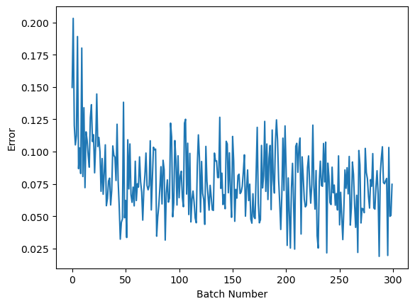

```python
plt.plot(errors)
plt.xlabel("Batch Number")
plt.ylabel("Error")
plt.show()
```

What is the final weight matrix $W$ after training?

```python
print(W.numpy()) # a weight matrix of shape (50,784)
```

```
[[-0.3799999  -0.3799999  -0.44999984 ... -0.13999999 -0.4999998
  -0.27      ]
 [-0.40999988 -0.43999985 -0.33999994 ... -0.20000002 -0.5999997
  -0.20000002]
 [-0.41999987 -0.5999997  -0.45999983 ... -0.20000002 -0.5299998
  -0.26000002]
 ...
 [-0.3799999  -0.5199998  -0.3999999  ... -0.25000003 -0.43999985
  -0.19000001]
 [-0.45999983 -0.43999985 -0.4799998  ... -0.21000002 -0.5299998
  -0.28      ]
 [-0.35999992 -0.45999983 -0.35999992 ... -0.20000002 -0.5499998
  -0.28      ]]
```

### Learned features

We can take each hidden unit and visualize the connections between that hidden unit and each element in the input vector. In our case, we have 50 hidden units. Lets visualize those.

**Let's plot the current weights**: **tile_raster_images** helps in generating an easy to grasp image from a set of samples or weights. It transforms the **uw** (with one flattened image per row of size 784), into an array (of size $28\times28$) in which images are reshaped and laid out like tiles on a floor.

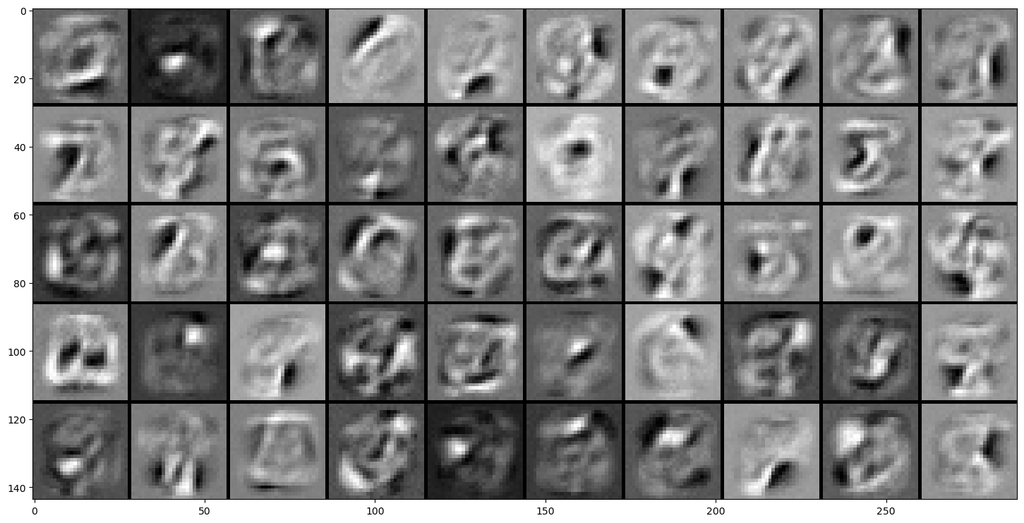

```python
tile_raster_images(X=W.numpy().T, img_shape=(28, 28), tile_shape=(5, 10), tile_spacing=(1, 1))
import matplotlib.pyplot as plt
from PIL import Image
%matplotlib inline
image = Image.fromarray(tile_raster_images(X=W.numpy().T, img_shape=(28, 28) ,tile_shape=(5, 10), tile_spacing=(1, 1)))
### Plot image
plt.rcParams['figure.figsize'] = (18.0, 18.0)
imgplot = plt.imshow(image)
imgplot.set_cmap('gray')
```

**Each tile in the above visualization corresponds to a vector of connections between a hidden unit and visible layer's units.**

Let's look at one of the learned weights corresponding to one of hidden units for example. **In this particular square, the gray color represents weight = 0, and the whiter it is, the more positive the weights are (closer to 1). Conversely, the darker pixels are, the more negative the weights. The positive pixels will increase the probability of activation in hidden units (after multiplying by input/visible pixels), and negative pixels will decrease the probability of a unit hidden to be 1 (activated). So, why is this important? So we can see that this specific square (hidden unit) can detect a feature (e.g. a "/" shape) and if it exists in the input.**

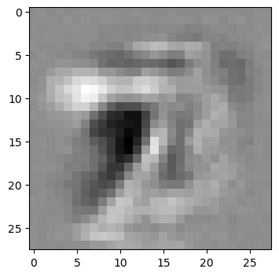

```python
from PIL import Image
image = Image.fromarray(tile_raster_images(X =W.numpy().T[10:11], img_shape=(28, 28),tile_shape=(1, 1), tile_spacing=(1, 1)))
### Plot image
plt.rcParams['figure.figsize'] = (4.0, 4.0)
imgplot = plt.imshow(image)
imgplot.set_cmap('gray')
```

**Let's look at the reconstruction of an image now. Imagine that we have a destructed image of figure 3. Lets see if our trained network can fix it:**

First we plot the image:

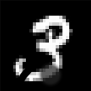

```python
img = Image.open('destructed3.jpg')
img
```

Now let's pass this image through the neural net:

```python
# convert the image to a 1d numpy array
sample_case = np.array(img.convert('I').resize((28,28))).ravel().reshape((1, -1))/255.0

sample_case = tf.cast(sample_case, dtype=tf.float32)
```

Feed the sample case into the network and reconstruct the output:

```python
hh0_p = tf.nn.sigmoid(tf.matmul(sample_case, W) + hb)
hh0_s = tf.round(hh0_p)

print("Probability nodes in hidden layer:" ,hh0_p)
print("activated nodes in hidden layer:" ,hh0_s)

# reconstruct
vv1_p = tf.nn.sigmoid(tf.matmul(hh0_s, tf.transpose(W)) + vb)

print(vv1_p)
#rec_prob = sess.run(vv1_p, feed_dict={ hh0_s: hh0_s_val, W: prv_w, vb: prv_vb})
```

```
Probability nodes in hidden layer: tf.Tensor(
[[7.8983469e-09 9.9667466e-01 5.9648606e-05 2.5764164e-08 5.8831708e-09
  6.8966488e-06 9.9780196e-01 1.9434063e-01 9.9999976e-01 3.1197745e-01
  1.0934315e-06 5.6641740e-03 9.9913555e-01 9.9226004e-01 3.6463412e-11
  2.5754047e-15 2.6432185e-13 9.8224230e-02 9.8992443e-01 8.7293285e-01
  3.7540433e-01 2.0900546e-07 1.0000000e+00 8.2979780e-01 1.6245313e-05
  3.3676732e-02 1.8805176e-13 1.4549372e-01 8.3976976e-09 1.7681015e-11
  1.8157409e-06 1.0000000e+00 1.2311666e-11 1.8173644e-03 5.6257218e-06
  9.9984241e-01 8.6619168e-14 9.9998510e-01 9.9999988e-01 5.7789865e-08
  1.5822755e-08 3.1643729e-05 2.7977148e-07 9.9999994e-01 3.6419917e-10
  1.0000000e+00 9.4785553e-01 7.6208673e-10 7.0854165e-03 5.8233618e-06]], shape=(1, 50), dtype=float32)
activated nodes in hidden layer: tf.Tensor(
[[0. 1. 0. 0. 0. 0. 1. 0. 1. 0. 0. 0. 1. 1. 0. 0. 0. 0. 1. 1. 0. 0. 1. 1.
  0. 0. 0. 0. 0. 0. 0. 1. 0. 0. 0. 1. 0. 1. 1. 0. 0. 0. 0. 1. 0. 1. 1. 0.
  0. 0.]], shape=(1, 50), dtype=float32)
tf.Tensor(
[[4.80338000e-04 4.05275059e-04 3.06330709e-04 5.30829013e-04
  4.21807432e-04 4.66148631e-04 4.56922455e-04 3.03283479e-04
  4.39014169e-04 2.88496405e-04 4.30325075e-04 4.61512391e-04
  3.41951498e-04 4.08961583e-04 6.94762566e-04 3.16437538e-04
  4.52377921e-04 3.45373031e-04 3.66722234e-04 4.26044775e-04
  4.30324872e-04 4.56922455e-04 4.01244033e-04 3.74127703e-04
  3.15656827e-04 3.63074505e-04 4.01243829e-04 3.63074330e-04
  2.91395088e-04 3.52347735e-04 2.94322817e-04 3.85517109e-04
  4.36286791e-04 3.42729705e-04 4.22254176e-04 3.10064032e-04
  4.74928296e-04 4.15098853e-04 5.80199820e-04 4.87699755e-04
  6.27901580e-04 7.33024615e-04 7.17311224e-04 4.99109563e-04
  7.49671133e-04 6.80455472e-04 8.85544578e-04 5.53239370e-04
  6.42009953e-04 6.25566987e-04 3.80472600e-04 3.06631060e-04
  4.47879051e-04 4.30324872e-04 5.92515978e-04 4.21807432e-04
  5.80790162e-04 3.89389810e-04 2.80698150e-04 5.59804554e-04
  2.97012011e-04 3.78746598e-04 5.46343916e-04 3.71993287e-04
  3.31914081e-04 3.33740754e-04 1.42315926e-04 9.17764191e-05
  7.58073220e-05 1.27773688e-04 1.91443178e-04 2.04285927e-04
  2.37505490e-04 5.41644840e-05 9.66938533e-05 7.19946402e-05
  8.74001780e-05 2.72298377e-04 6.06591755e-04 3.86849279e-04
  4.43407363e-04 5.36981446e-04 4.61512856e-04 3.55887722e-04
  4.05274652e-04 4.21807257e-04 3.34657409e-04 5.10946149e-04
  3.15150130e-04 4.07058455e-04 3.86576809e-04 4.31440421e-04
  2.13924257e-04 2.36678126e-04 1.32571731e-04 1.75099762e-04
```

[output cut: 157 more lines]

```
  3.97970405e-04 3.58421938e-04 3.39427323e-04 3.74127500e-04
  4.47878847e-04 4.47878614e-04 4.39014373e-04 3.54606513e-04
  5.26952499e-04 1.80448184e-03 1.43155956e-03 1.50679133e-03
  1.15278736e-03 1.13274332e-03 1.45411270e-03 3.64665058e-03
  1.88832963e-03 1.01419166e-03 6.70437992e-04 1.67377933e-03
  1.81015593e-03 1.11915171e-03 6.17723796e-04 1.05888816e-03
  1.34103675e-03 6.15379540e-04 5.56981598e-04 4.47317783e-04
  2.28973411e-04 4.35006019e-04 3.31835588e-04 4.43424302e-04
  3.93301772e-04 3.97253054e-04 3.09408206e-04 4.30324872e-04
  4.66167054e-04 3.32499971e-04 7.50846171e-04 8.65376380e-04
  6.13380980e-04 1.36231678e-03 3.00161913e-03 1.95769430e-03
  1.88668282e-03 1.31807721e-03 1.89719361e-03 1.10093085e-03
  1.60138507e-03 1.22168392e-03 6.33314950e-04 5.42268972e-04
  3.24172142e-04 3.65502201e-04 3.08427465e-04 4.69136605e-04
  3.77886259e-04 3.22031323e-04 3.18828301e-04 3.55887722e-04]], shape=(1, 784), dtype=float32)
```

Here we plot the reconstructed image:

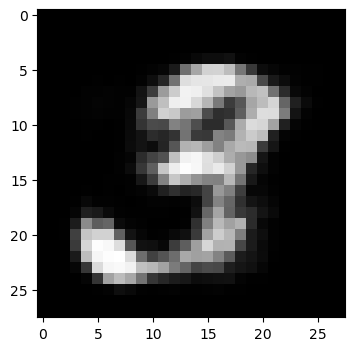

```python
img = Image.fromarray(tile_raster_images(X=vv1_p.numpy(), img_shape=(28, 28),tile_shape=(1, 1), tile_spacing=(1, 1)))
plt.rcParams['figure.figsize'] = (4.0, 4.0)
imgplot = plt.imshow(img)
imgplot.set_cmap('gray')
```

# Authors' rights

Machine Learning with Python course by IBM on Coursera: https://www.coursera.org/learn/machine-learning-with-python/

Completed and modified by Mathilde Marie Duville as part of the IBM Artificial Intelligence Engineering Professional Certificate and corresponding IBM badges. Please, follow the subsequent links to confirm the accreditation:

https://www.coursera.org/account/accomplishments/professional-cert/KSLW773DAATP?utm_source=link&utm_medium=certificate&utm_content=cert_image&utm_campaign=sharing_cta&utm_product=prof

https://www.credly.com/users/mathilde-marie-duville/badges

Author: [Saeed Aghabozorgi](https://ca.linkedin.com/in/saeedaghabozorgi)

Updated to TF 2.X by Jerome Nilmeier

### References:

https://en.wikipedia.org/wiki/Restricted_Boltzmann_machine  
http://deeplearning.net/tutorial/rbm.html  
http://www.cs.utoronto.ca/~hinton/absps/netflixICML.pdf  
http://imonad.com/rbm/restricted-boltzmann-machine/

Copyright © 2018 [Cognitive Class](https://cocl.us/DX0108EN_CC). This notebook and its source code are released under the terms of the MIT License.